# chip-seq overlap and annotation

# Chip-seq analysis

Analysis forKate Jeffrey’s group.

Contact Lorena Pantano (lpantano@hsph.harvard.edu) for additional details.

The most recent update of this html document occurred: Thu Oct 6 17:32:13 2016

The sections below provide code to reproduce the included results and plots.

## Setup

### Libraries

```r
> ## loading packages
> library(knitr)
> library(ChIPseeker)
> library(clusterProfiler)
> library(dplyr)
> library(ggplot2)
> library(UpSetR)
> library(GenomicRanges)
> library(readr)
```

```r
> baseDirSP = "/Users/lpantano/orch/scratch/chipseq_ma_shannan/re-analysis/sp140"
> baseDir = "/Users/lpantano/orch/scratch/chipseq_ma_shannan/re-analysis/peaks_files"
> path_results = file.path(baseDir, "filtered")
> dir.create(path_results, showWarnings = FALSE)
>
> files <- list(sp140_0h = c(file.path(baseDirSP, "SP140_0h_IP_a_peaks.broadPeak")),
+     sp140_4h = c(file.path(baseDirSP, "SP140_4h_IP_a_peaks.broadPeak")))
> broad_header = c("chrom", "start", "end", "peak", "score", "fake", "foldchange",
+     "log10pvalue", "log10qvalue")
> narrow_header = c("chrom", "start", "end", "peak", "score", "fake", "foldchange",
+     "log10pvalue", "log10qvalue", "summit")
>
> peaks = list(sp140_0h = makeGRangesFromDataFrame(read_tsv(files[[1]], col_names = broad_header) %>%
+     filter(foldchange > 0), keep.extra.columns = TRUE, ignore.strand = TRUE,
+     end.field = "end", start.field = "start", seqnames.field = "chrom"), sp140_4h = makeGRangesFromDataFrame(read_tsv(files[[2]],
+     col_names = broad_header) %>% filter(foldchange > 0), keep.extra.columns = TRUE,
+     ignore.strand = TRUE, end.field = "end", start.field = "start", seqnames.field = "chrom"))
>
> k4me3 = read.table(file.path(baseDir, "H3K4me3_merged_peaks.scores.narrowPeak"),
+     header = F, stringsAsFactors = F) %>% filter(!grepl("_", V1))
> names(k4me3) = c("chrom", "start", "end", "score", "foldchange")
> k4me3 = makeGRangesFromDataFrame(k4me3, keep.extra.columns = TRUE, ignore.strand = TRUE,
+     end.field = "end", start.field = "start", seqnames.field = "chrom")
>
> k4me1 = read.table(file.path(baseDir, "H4K4me1_peaks.narrowPeak"), header = F,
+     stringsAsFactors = F) %>% filter(!grepl("_", V1))
> names(k4me1) = narrow_header
> k4me1 = makeGRangesFromDataFrame(k4me1, keep.extra.columns = TRUE, ignore.strand = TRUE,
+     end.field = "end", start.field = "start", seqnames.field = "chrom")
>
> k27ac = read.table(file.path(baseDir, "H3K27ac_peaks.narrowPeak"), header = F,
+     stringsAsFactors = F) %>% filter(!grepl("_", V1))
> names(k27ac) = narrow_header
> k27ac = makeGRangesFromDataFrame(k27ac, keep.extra.columns = TRUE, ignore.strand = TRUE,
+     end.field = "end", start.field = "start", seqnames.field = "chrom")
>
> k27me3 = read.table(file.path(baseDir, "H3K27me3_peaks.broadPeak"), header = F,
+     stringsAsFactors = F) %>% filter(!grepl("_", V1))
> names(k27me3) = broad_header
> k27me3 = makeGRangesFromDataFrame(k27me3, keep.extra.columns = TRUE, ignore.strand = TRUE,
+     end.field = "end", start.field = "start", seqnames.field = "chrom")
```

```r
> basic_stat = data.frame(type = c("K27ac", "K27me3", "K4me3", "K4me1", "SP140_0h",
+     "SP140_4h"), peaks = c(length(k27ac), length(k27me3), length(k4me3), length(k4me1),
+     length(peaks$sp140_0h), length(peaks$sp140_4h)))
```

## Choosing the best cutoff

We used the same rule for the cutoff for each file. It is the value just after the larger peak, that is considered the background peak value. Everything after that is considered a strong peak.

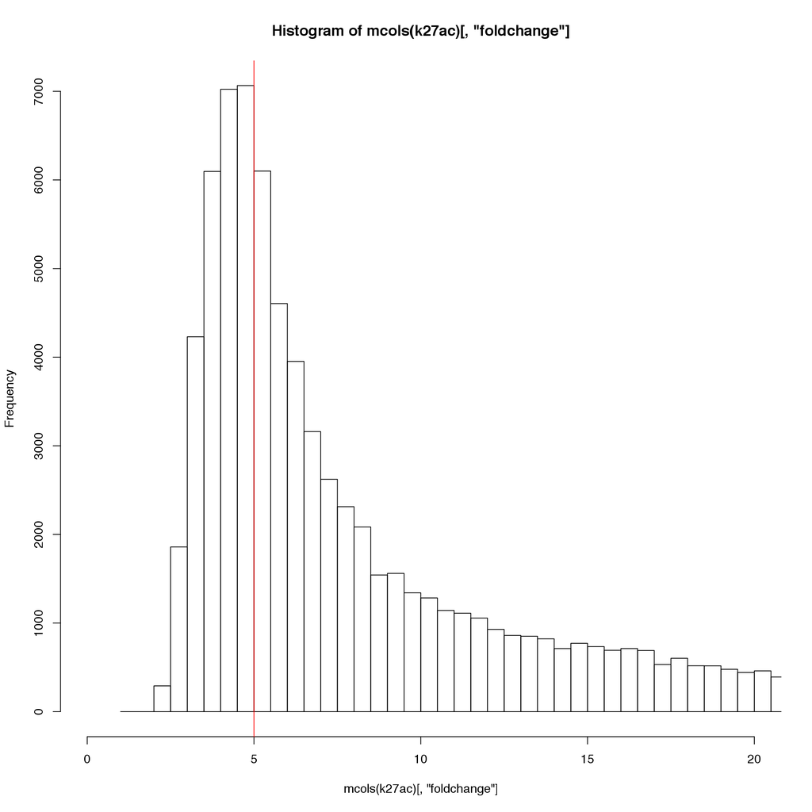

```r
> hist(mcols(k27ac)[, "foldchange"], breaks = seq(1, 60, 0.5), xlim = c(0, 20))
> abline(v = 5, col = "red")
```

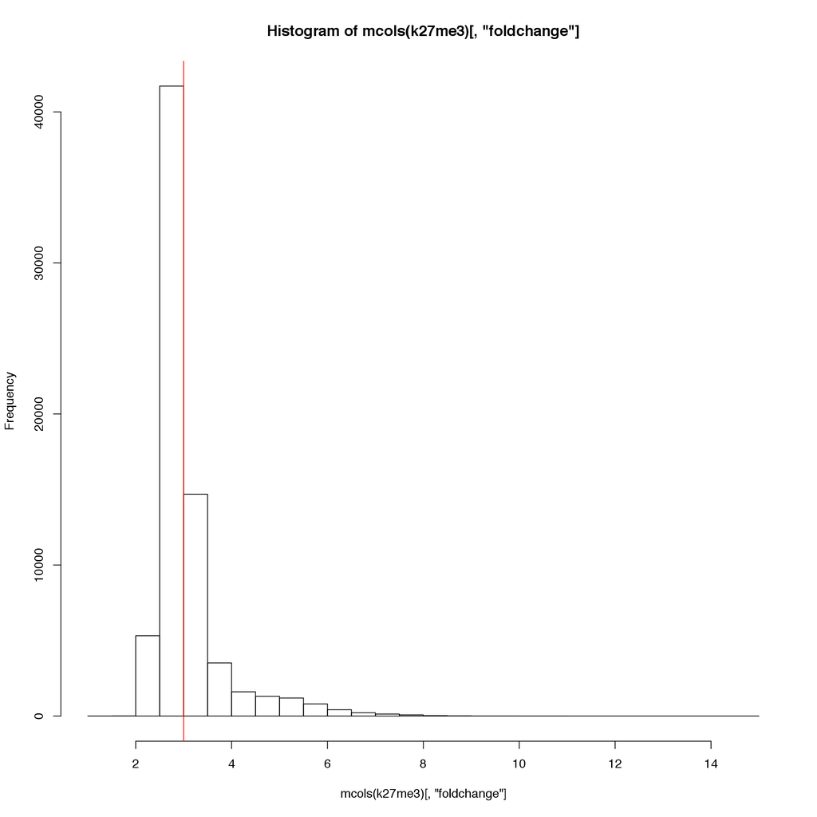

```r
> hist(mcols(k27me3)[, "foldchange"], breaks = seq(1, 15, 0.5))
> abline(v = 3, col = "red")
```

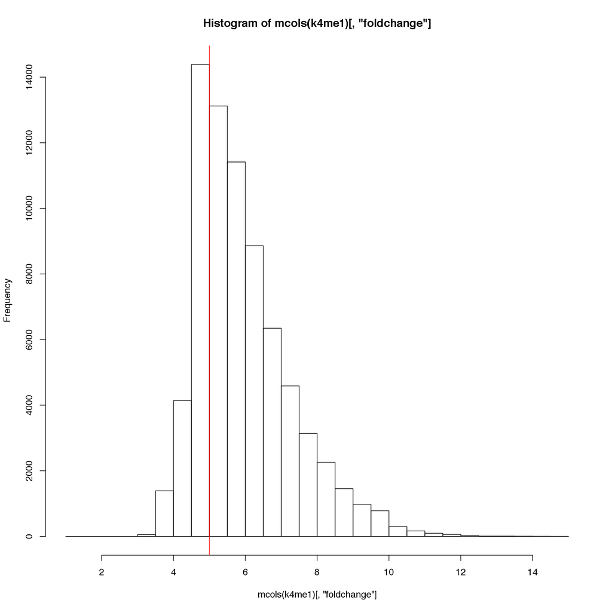

```r
> hist(mcols(k4me1)[, "foldchange"], breaks = seq(1, 15, 0.5))
> abline(v = 5, col = "red")
```

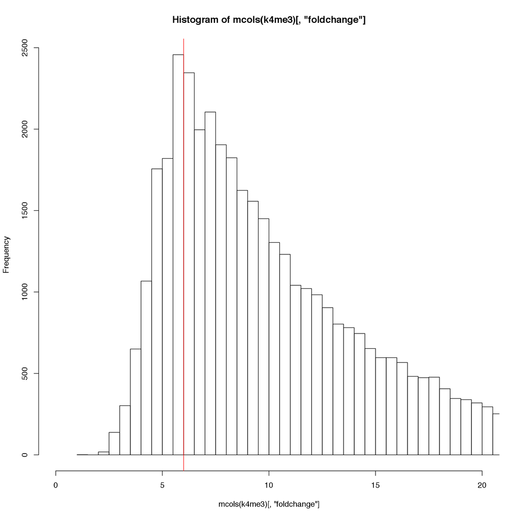

```r
> hist(mcols(k4me3)[, "foldchange"], breaks = seq(1, 51, 0.5), xlim = c(0, 20))
> abline(v = 6, col = "red")
```

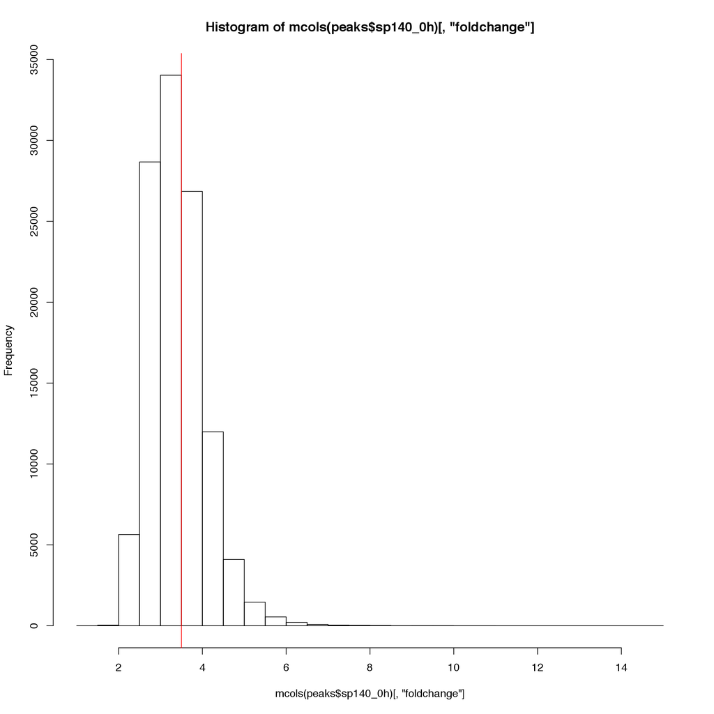

```r
> hist(mcols(peaks$sp140_0h)[, "foldchange"], breaks = seq(1, 15, 0.5))
> abline(v = 3.5, col = "red")
```

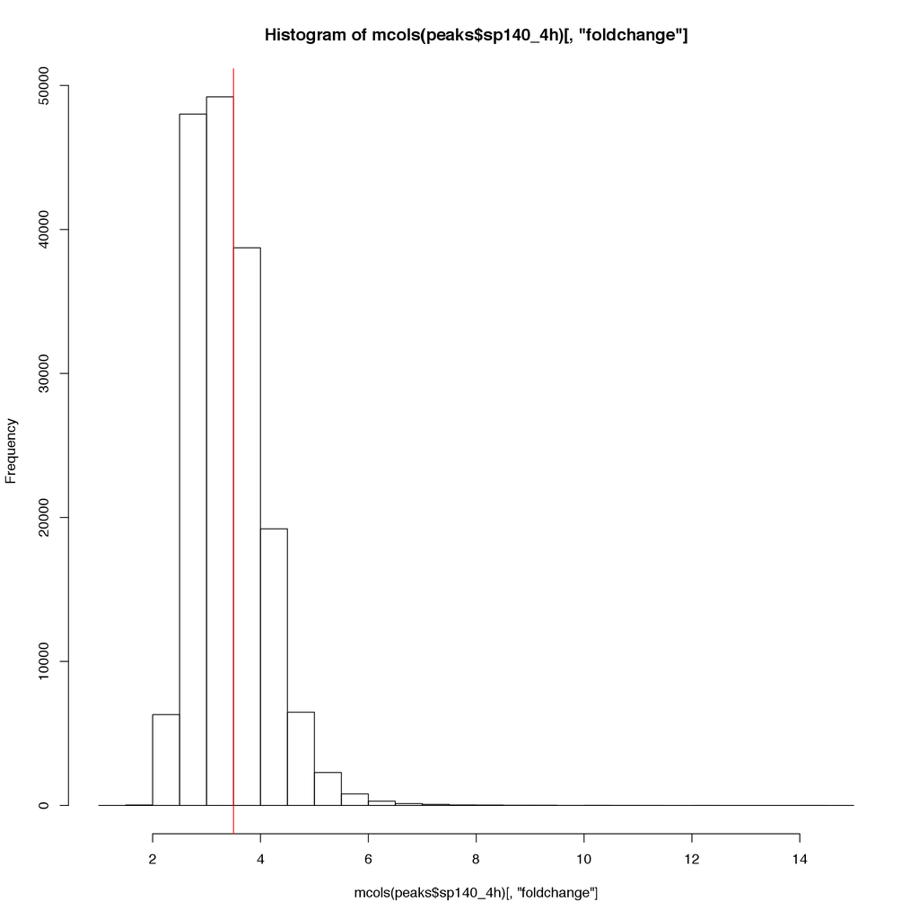

```r
> hist(mcols(peaks$sp140_4h)[, "foldchange"], breaks = seq(1, 15, 0.5))
> abline(v = 3.5, col = "red")
```

## Peaks after filtering

```r
> cutoff = list(k27me3 = 3, k4me1 = 5, k4me3 = 6, sp140_0h = 3.5, sp140_4h = 3.5,
+     k27ac = 5)
> peaks$sp140_0h = peaks$sp140_0h[mcols(peaks$sp140_0h)[, "foldchange"] > cutoff[["sp140_0h"]],
+     ]
> peaks$sp140_4h = peaks$sp140_4h[mcols(peaks$sp140_4h)[, "foldchange"] > cutoff[["sp140_4h"]],
+     ]
> k27me3 = k27me3[mcols(k27me3)[, "foldchange"] > cutoff[["k27me3"]], ]
> k27ac = k27ac[mcols(k27ac)[, "foldchange"] > cutoff[["k27ac"]], ]
> k4me3 = k4me3[mcols(k4me3)[, "foldchange"] > cutoff[["k4me3"]], ]
> k4me1 = k4me1[mcols(k4me1)[, "foldchange"] > cutoff[["k4me1"]], ]
>
> sprintf("K27ac cutoff %s: %s peaks\n", cutoff[["k27ac"]], length(k27ac))
```

[1] “K27ac cutoff 5: 50013 peaks”

```r
> sprintf("K27me3 cutoff %s: %s peaks\n", cutoff[["k27me3"]], length(k27me3))
```

[1] “K27me3 cutoff 3: 23995 peaks”

```r
> sprintf("K4me3 cutoff %s: %s peaks\n", cutoff[["k4me3"]], length(k4me3))
```

[1] “K4me3 cutoff 6: 32341 peaks”

```r
> sprintf("K4me1 cutoff %s: %s peaks\n", cutoff[["k4me1"]], length(k4me1))
```

[1] “K4me1 cutoff 5: 53599 peaks”

```r
> sprintf("SP140_0h cutoff %s: %s peaks\n", cutoff[["sp140_0h"]], length(peaks$sp140_0h))
```

[1] “SP140_0h cutoff 3.5: 45336 peaks”

```r
> sprintf("SP140_4h cutoff %s: %s peaks\n", cutoff[["sp140_4h"]], length(peaks$sp140_4h))
```

[1] “SP140_4h cutoff 3.5: 68089 peaks”

```r
> basic_stat = cbind(basic_stat, data.frame(cleaned_peaks = c(length(k27ac), length(k27me3),
+     length(k4me3), length(k4me1), length(peaks$sp140_0h), length(peaks$sp140_4h))))
>
> knitr::kable(basic_stat)
```

| type | peaks | cleaned_peaks |
| --- | --- | --- |
| K27ac | 76577 | 50013 |
| K27me3 | 71030 | 23995 |
| K4me3 | 40550 | 32341 |
| K4me1 | 73566 | 53599 |
| SP140_0h | 113714 | 45336 |
| SP140_4h | 171648 | 68089 |

## Standard annotation

```r
> peak_rda <- file.path(baseDirSP, "peak.rda")
> his_rda <- file.path(baseDirSP, "histones.rda")
>
> if (!file.exists(peak_rda)) {
+     peakAnnoList <- lapply(peaks, annotatePeak, TxDb = txdb, tssRegion = c(-5000,
+         5000), annoDb = "org.Hs.eg.db", verbose = FALSE)
+
+     histAnnoList <- lapply(list(k27ac, k4me3, k27me3, k4me1), annotatePeak,
+         TxDb = txdb, tssRegion = c(-5000, 5000), annoDb = "org.Hs.eg.db", verbose = FALSE)
+     names(histAnnoList) = c("k27ac", "k4me3", "k27me3", "k4me1")
+     idx1 = !grepl("Promoter", mcols(histAnnoList[["k27ac"]]@anno)[, "annotation"])
+     # idx2 = !grepl('Promoter',
+     # mcols(histAnnoList[['k4me1']]@anno)[,'annotation']) enhancer =
+     # reduce(sort(c(k27ac[idx1, ],k4me1[idx2,],ignore.mcols=TRUE)))
+     enhancer = k27ac[idx1, ]
+     histAnnoList[["enhancer"]] = annotatePeak(enhancer, TxDb = txdb, tssRegion = c(-5000,
+         5000), annoDb = "org.Hs.eg.db", verbose = FALSE)
+     save(peakAnnoList, file = peak_rda)
+     save(histAnnoList, file = his_rda)
+ } else {
+     load(peak_rda)
+     load(his_rda)
+ }
>
> idx = histAnnoList$k27me3@detailGenomicAnnotation$Promoter == TRUE
> save_file(as.data.frame(histAnnoList$k27me3@anno[idx, ]), "H3K27me3_tss.txt",
+     path_results)
> idx = histAnnoList$k4me3@detailGenomicAnnotation$Promoter == TRUE
> save_file(as.data.frame(histAnnoList$k4me3@anno[idx, ]), "H3K4me3_tss.txt",
+     path_results)
>
> save_file(as.data.frame(histAnnoList$k27ac@anno), "H3K27ac.txt", path_results)
> save_file(as.data.frame(histAnnoList$k27me3@anno), "H3K27me3.txt", path_results)
> save_file(as.data.frame(histAnnoList$k4me3@anno), "H3K4me3.txt", path_results)
> save_file(as.data.frame(histAnnoList$k4me1@anno), "H3K4me1.txt", path_results)
> save_file(as.data.frame(peakAnnoList$sp140_0h@anno), "SP140_0h.txt", path_results)
> save_file(as.data.frame(peakAnnoList$sp140_4h@anno), "SP140_4h.txt", path_results)
```

### Overlap with all histone marks

It is tricky to overlap 4 peaks of sets, because first you need to define an unique set of peaks in the whole data set. For instance, it happens than two peaks overlap with one peak in other data set. When comparing 4 sets, the problem is complex, and my approach is to define an unique set of peaks, and then overlap this one with every other set of peaks.

To define an unique set of peaks, I put all peaks together and merge the ones that overlap. This will cause that the total peaks in each data set, will differ slightly in the total peaks seen in the figure. For instance, it happens than one region has:

```
SP140_0h has 3 peaks
H3K27ac has 1 peak
H3K4me3 has 2 peaks
H3K4me1 has 0 peaks
```

This will end up as 1 unique peak, and will be counted only once for SP140_0h, H3K27ac and H3K4me3.

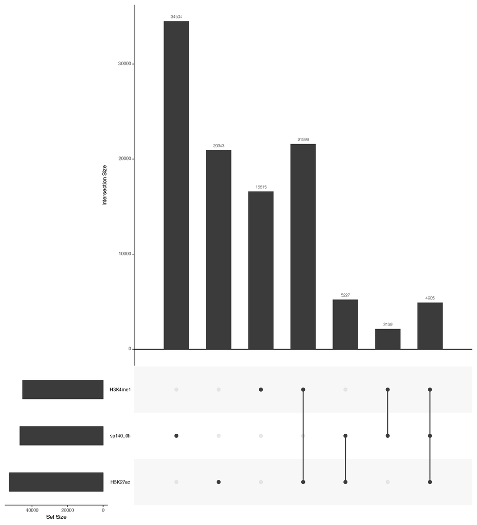

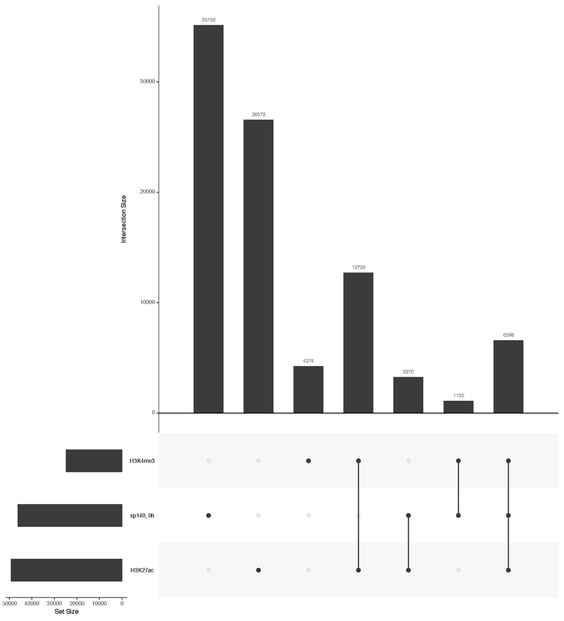

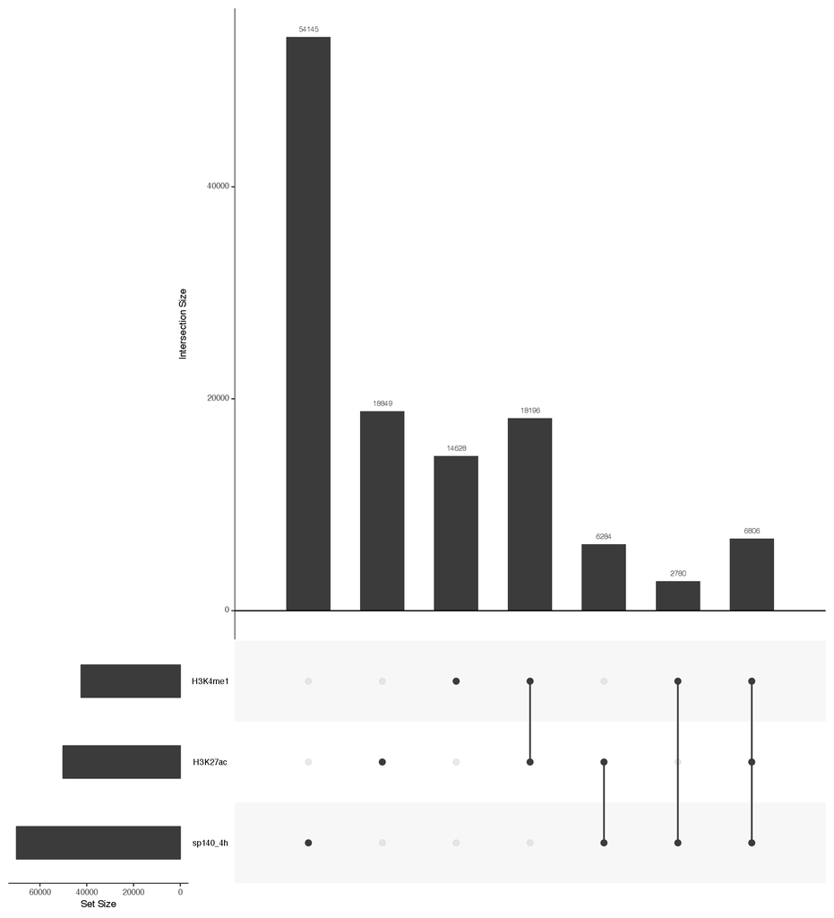

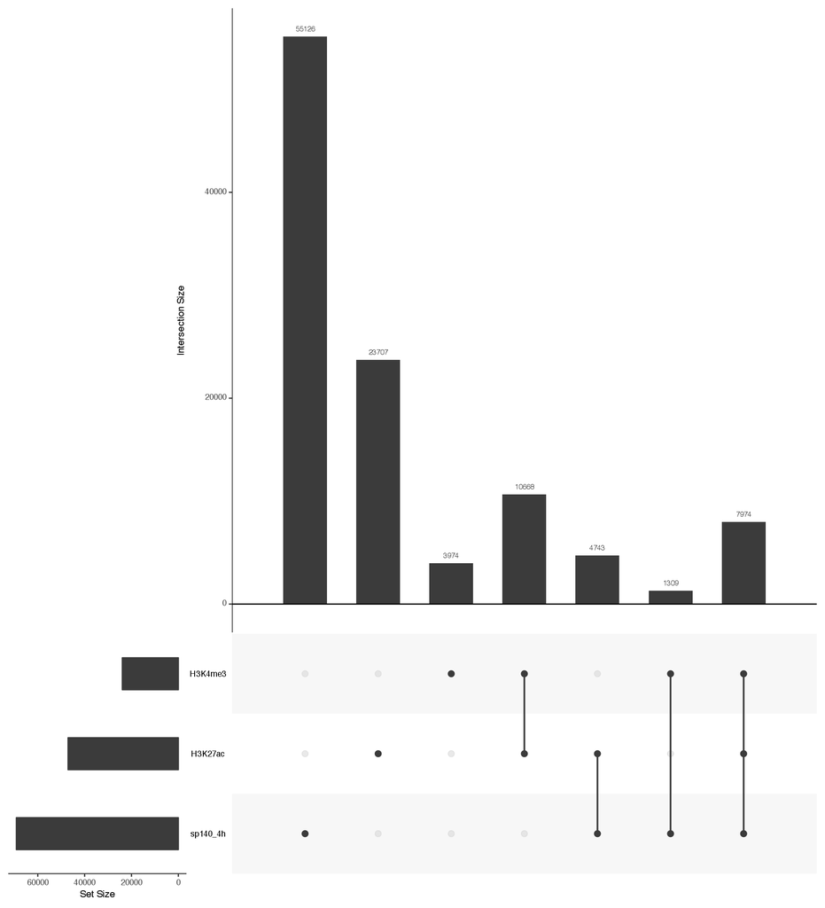

```r
> plot_common = function(all_peaks, sets) {
+     .void = lapply(names(sets), function(s) {
+         r = sets[[s]]
+         idx = findOverlaps(all_peaks, r, maxgap = 501)
+         mcols(all_peaks)[, s] <<- FALSE
+         mcols(all_peaks)[queryHits(idx), s] <<- TRUE
+     })
+     ma = as.matrix(as.data.frame(mcols(all_peaks)[, names(sets)]))
+     ma[ma] = 1
+     UpSetR::upset(as.data.frame(ma), sets = names(sets))
+ }
>
> .void = lapply(names(peakAnnoList), function(name) {
+     class_anno = peakAnnoList[[name]]
+     range = slot(class_anno, "anno")
+
+     all_peaks = reduce(sort(c(k4me1, k27ac, range, ignore.mcols = TRUE)))
+     sets = list(sp140 = range, H3K4me1 = k4me1, H3K27ac = k27ac)
+     names(sets)[1] = name
+     plot_common(all_peaks, sets)
+
+     all_peaks = reduce(sort(c(k4me3, k27ac, range, ignore.mcols = TRUE)))
+     sets = list(sp140 = range, H3K4me3 = k4me3, H3K27ac = k27ac)
+     names(sets)[1] = name
+     plot_common(all_peaks, sets)
+
+
+ })
```

### Overlap only at TSS +/- 5Kb regions.

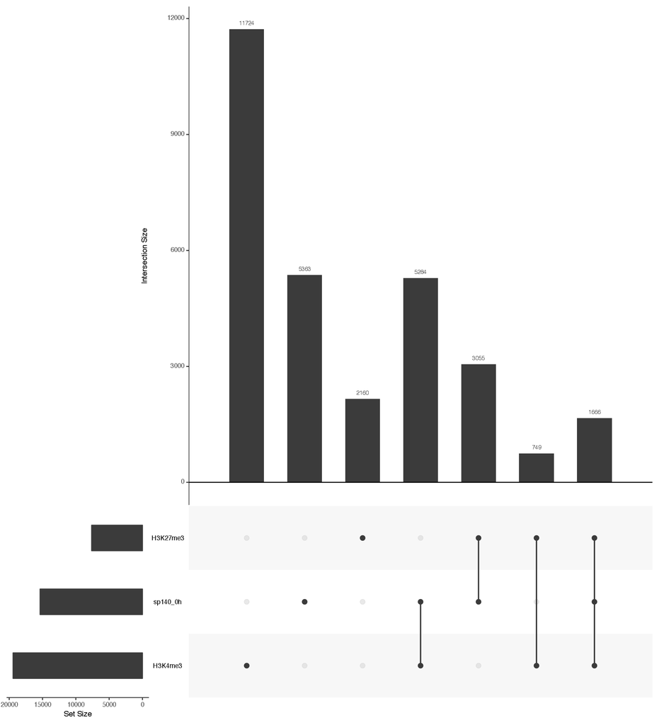

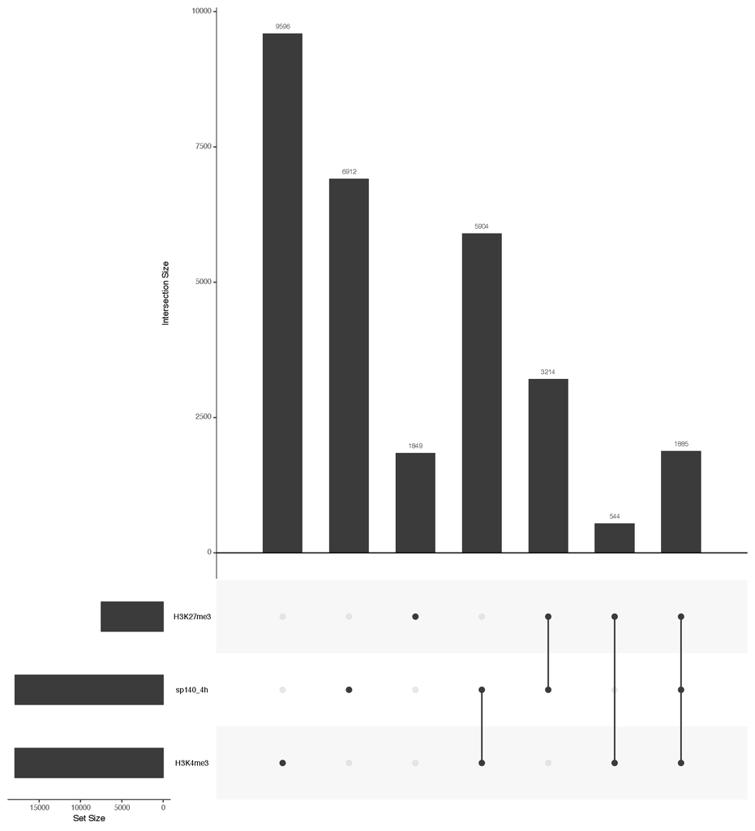

```r
> .void = lapply(names(peakAnnoList), function(name) {
+     class_anno = peakAnnoList[[name]]
+     range = slot(class_anno, "anno")
+
+     k4me3 = slot(histAnnoList[["k4me3"]], "anno")
+     k27me3 = slot(histAnnoList[["k27me3"]], "anno")
+
+     idx_sp140 = grepl("Promoter", mcols(range)[, "annotation"])
+     idx_k4me3 = grepl("Promoter", mcols(k4me3)[, "annotation"])
+     idx_k27me3 = grepl("Promoter", mcols(k27me3)[, "annotation"])
+
+     all_peaks = reduce(sort(c(k27me3[idx_k27me3, ], k4me3[idx_k4me3, ], range[idx_sp140,
+         ], ignore.mcols = TRUE)))
+     sets = list(sp140 = range[idx_sp140, ], H3K27me3 = k27me3[idx_k27me3, ],
+         H3K4me3 = k4me3[idx_k4me3, ])
+     names(sets)[1] = name
+     plot_common(all_peaks, sets)
+ })
```

## New annotation with enhancer

```r
> getGenomicAnnoStat <- function(peakAnno) {
+     if ( class(peakAnno) == "GRanges" )
+         peakAnno <- as.data.frame(peakAnno)
+     anno <- peakAnno$annotation
+     ## anno <- sub(" \\(.+", "", anno)
+
+     anno[grep("exon 1 of", anno)] <- "1st Exon"
+     anno[grep("intron 1 of", anno)] <- "1st Intron"
+     anno[grep("Exon \\(", anno)] <- "Other Exon"
+     anno[grep("Intron \\(", anno)] <- "Other Intron"
+     anno[grep("Downstream", anno)] <- "Downstream (<=3kb)"
+
+     ## count frequency
+     anno.table <- table(anno)
+
+     ## calculate ratio
+     anno.ratio <- anno.table/ sum(anno.table) * 100
+     anno.df <- as.data.frame(anno.ratio)
+     colnames(anno.df) <- c("Feature", "Frequency")
+     anno.df$Numbers <- anno.table
+     lvs <- c(## "Promoter (<=1kb)",
+              ## "Promoter (1-2kb)",
+              ## "Promoter (2-3kb)",
+              "Promoter (<= 3kb)",
+              "Promoter",
+              "Promoter-H3K27me3",
+              "Enhancer",
+              "H3K4me1",
+              "Enhancer-H3K4me1",
+              "5' UTR",
+              "3' UTR",
+              "1st Exon",
+              "Other Exon",
+              "1st Intron",
+              "Other Intron",
+              "Downstream (<=3kb)",
+              "Distal Intergenic",
+              "Others")
+
+     anno.df$Feature <- factor(anno.df$Feature, levels=lvs[lvs %in% anno.df$Feature])
+     anno.df <- anno.df[order(anno.df$Feature),]
+     return(anno.df)
+ }
```

Promoter defined as the region at +/- 5Kb from TSS

Enhancer defined as peaks that overlap H3K27ac + (+/- 5kb far aways from any TSS or gene)

```r
> require(TxDb.Hsapiens.UCSC.hg19.knownGene)
> txdb <- TxDb.Hsapiens.UCSC.hg19.knownGene
>
> top10 = list()
> idx = order(mcols(peaks[[1]])$foldchange * width(peaks[[1]]), decreasing = T)
> top10[[1]] = peaks[[1]][idx[1:round(length(idx)/10)], ]
> idx = order(mcols(peaks[[2]])$foldchange * width(peaks[[2]]), decreasing = T)
> top10[[2]] = peaks[[2]][idx[1:round(length(idx)/10)], ]
>
> topPeakAnnoList <- lapply(top10, annotatePeak, TxDb = txdb, tssRegion = c(-5000,
+     5000), annoDb = "org.Hs.eg.db", verbose = FALSE)
> names(topPeakAnnoList) = c("top_SP140_0h", "top_SP140_4h")
```

```r
> all = c(peakAnnoList, topPeakAnnoList)
> peakAnnoList_mod = lapply(names(all), function(name) {
+     class_anno = all[[name]]
+     range = slot(class_anno, "anno")
+     idx = findOverlaps(range[, "annotation"], k27ac, maxgap = 501)
+     mcols(range)[, "enhancer"] = FALSE
+     mcols(range)[queryHits(idx), "enhancer"] = TRUE
+
+     idx = findOverlaps(range[, "annotation"], k4me1, maxgap = 501)
+     mcols(range)[, "k4me1"] = FALSE
+     mcols(range)[queryHits(idx), "k4me1"] = TRUE
+     ann = mcols(range)
+     ann_col = ann[, "annotation"]
+
+     idx = findOverlaps(range[, "annotation"], k27me3, maxgap = 501)
+     mcols(range)[, "k27me3"] = FALSE
+     mcols(range)[queryHits(idx), "k27me3"] = TRUE
+     ann = mcols(range)
+     ann_col = ann[, "annotation"]
+
+
+     new_col = ann_col
+     # new_col[1:length(ann_col)] = 'Others'
+     new_col[grepl("Promoter", ann_col)] = "Promoter"
+     new_col[ann[, "enhancer"] & new_col != "Promoter"] = "Enhancer"
+     new_col[ann[, "k4me1"] & new_col != "Promoter"] = "H3K4me1"
+     new_col[ann[, "enhancer"] & new_col == "H3K4me1"] = "Enhancer-H3K4me1"
+     # new_col[ann[,'k27me3'] & new_col == 'Promoter'] = 'Promoter-H3K27me3'
+
+     logic_df = cbind(slot(class_anno, "detailGenomicAnnotation"), Enhancer = new_col ==
+         "Enhancer")
+     logic_df$Promoter = new_col == "Promoter"
+     logic_df$Promoter_H3K27me3 = new_col == "Promoter-H3K27me3"
+     logic_df$Enhancer = new_col == "Enhancer"
+     logic_df$H3K4me1 = new_col == "H3K4me1"
+     # logic_df$Enhancer_H3K4me1 = new_col == 'Enhancer-H3K4me1'
+
+     mcols(range)[, "annotation"] = new_col
+     df = getGenomicAnnoStat(range)
+     slot(class_anno, "anno") <- range
+     slot(class_anno, "annoStat") <- df
+     slot(class_anno, "detailGenomicAnnotation") <- logic_df
+     cat("\n\n ###", name, "\n\n")
+     print(kable(df))
+     cat("\n\n")
+     print(plotAnnoBar(class_anno))
+     cat("\n\n")
+     plotAnnoPie(class_anno)
+     cat("\n\n")
+
+     save_file(as.data.frame(range), paste0(name, "_ann.txt"), baseDirSP, csv = FALSE)
+     pro_file_name = paste0(name, "_promoter.txt")
+     save_file(as.data.frame(range[new_col == "Promoter", ])[, 1:12], pro_file_name,
+         baseDirSP)
+     enh_file_name = paste0(name, "_enhancer.txt")
+     save_file(as.data.frame(range[new_col == "Enhancer", ][, 1:12]), enh_file_name,
+         baseDirSP)
+     class_anno
+ })
```

### sp140_0h

|  | Feature | Frequency | Numbers |
| --- | --- | --- | --- |
| 12 | Promoter | 34.2502649 | 15514 |
| 7 | Enhancer | 2.3114624 | 1047 |
| 9 | H3K4me1 | 2.0487460 | 928 |
| 8 | Enhancer-H3K4me1 | 2.9362416 | 1330 |
| 4 | 5’ UTR | 1.3665666 | 619 |
| 3 | 3’ UTR | 3.7045214 | 1678 |
| 1 | 1st Exon | 0.3112858 | 141 |
| 10 | Other Exon | 7.9410986 | 3597 |
| 2 | 1st Intron | 3.3115507 | 1500 |
| 11 | Other Intron | 14.0542211 | 6366 |
| 6 | Downstream (<=3kb) | 0.5916637 | 268 |
| 5 | Distal Intergenic | 27.1723773 | 12308 |

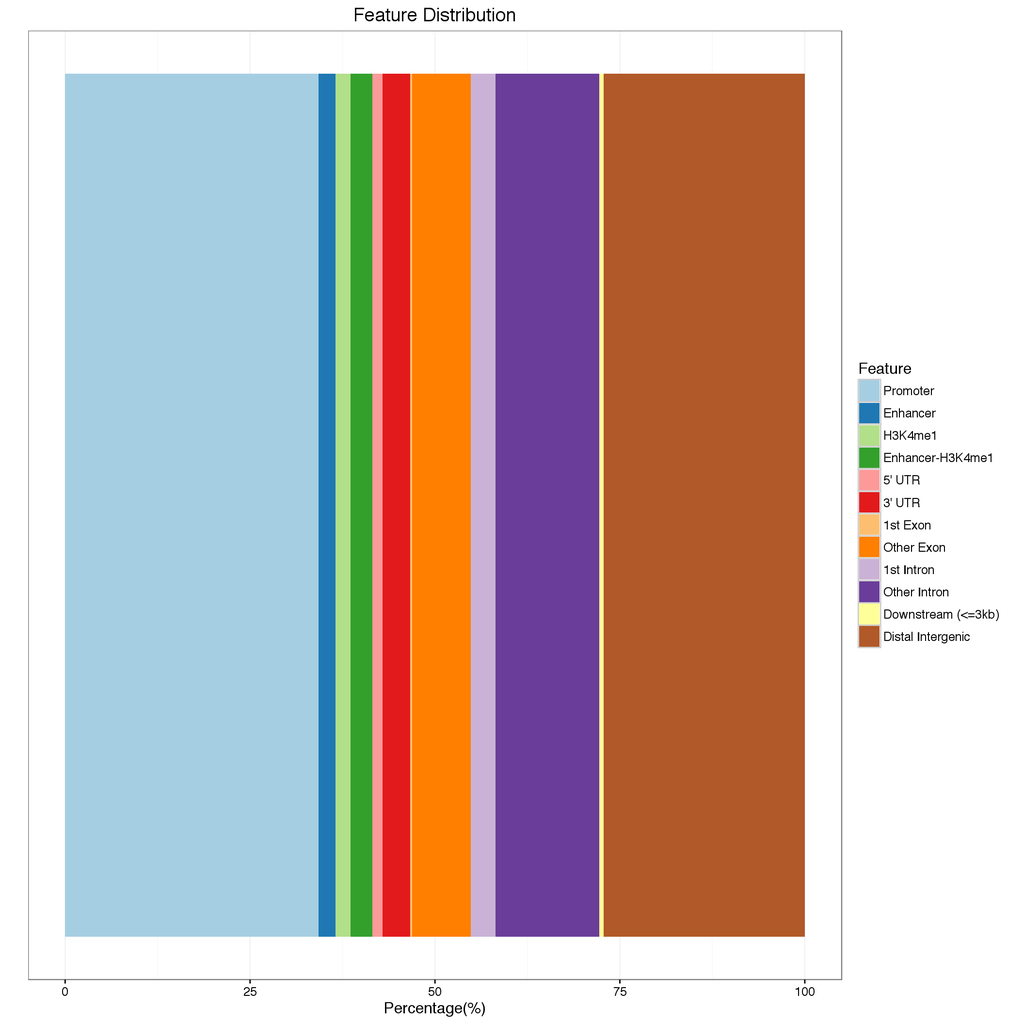

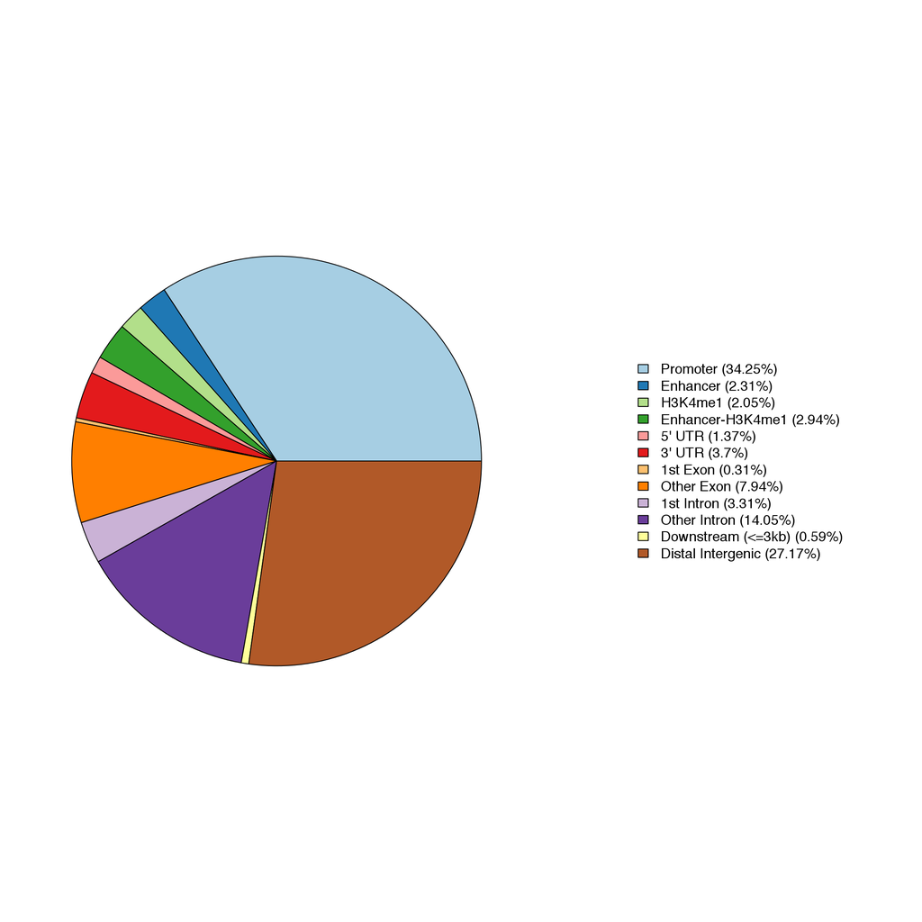

### sp140_4h

|  | Feature | Frequency | Numbers |
| --- | --- | --- | --- |
| 12 | Promoter | 26.8123503 | 18245 |
| 7 | Enhancer | 2.1632107 | 1472 |
| 9 | H3K4me1 | 1.9956795 | 1358 |
| 8 | Enhancer-H3K4me1 | 3.3006598 | 2246 |
| 4 | 5’ UTR | 1.2417888 | 845 |
| 3 | 3’ UTR | 3.1125546 | 2118 |
| 1 | 1st Exon | 0.2953841 | 201 |
| 10 | Other Exon | 6.9011125 | 4696 |
| 2 | 1st Intron | 3.9649066 | 2698 |
| 11 | Other Intron | 17.5334695 | 11931 |
| 6 | Downstream (<=3kb) | 0.5452114 | 371 |
| 5 | Distal Intergenic | 32.1336723 | 21866 |

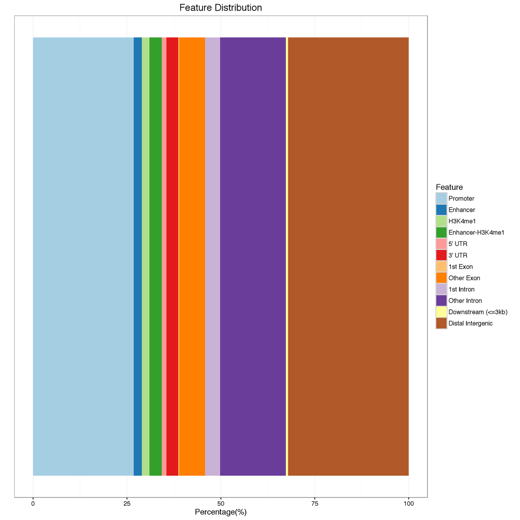

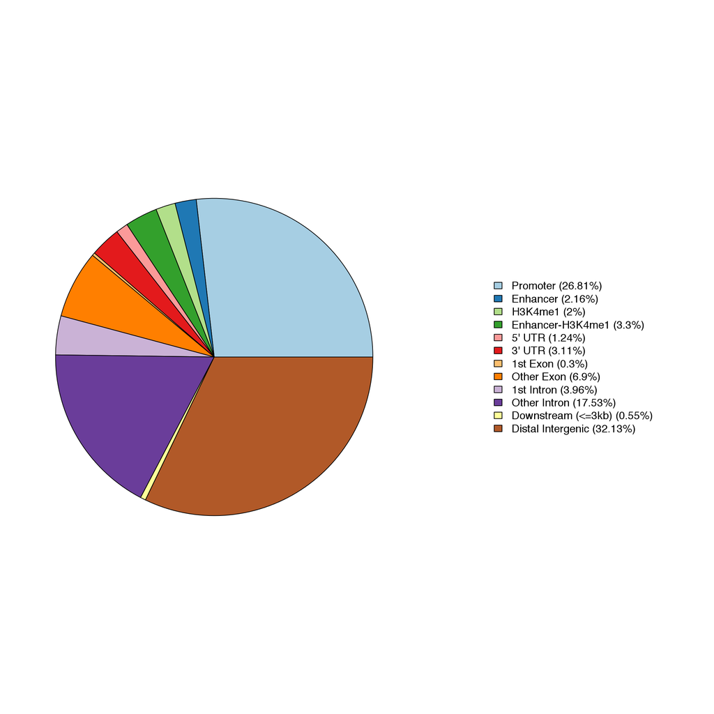

### top_SP140_0h

|  | Feature | Frequency | Numbers |
| --- | --- | --- | --- |
| 12 | Promoter | 57.9783712 | 2627 |
| 7 | Enhancer | 2.6042816 | 118 |
| 9 | H3K4me1 | 3.0677555 | 139 |
| 8 | Enhancer-H3K4me1 | 5.7823880 | 262 |
| 4 | 5’ UTR | 2.5380711 | 115 |
| 3 | 3’ UTR | 6.1575811 | 279 |
| 1 | 1st Exon | 0.3531229 | 16 |
| 10 | Other Exon | 7.1065990 | 322 |
| 2 | 1st Intron | 0.7503862 | 34 |
| 11 | Other Intron | 3.5974399 | 163 |
| 6 | Downstream (<=3kb) | 0.2427720 | 11 |
| 5 | Distal Intergenic | 9.8212315 | 445 |

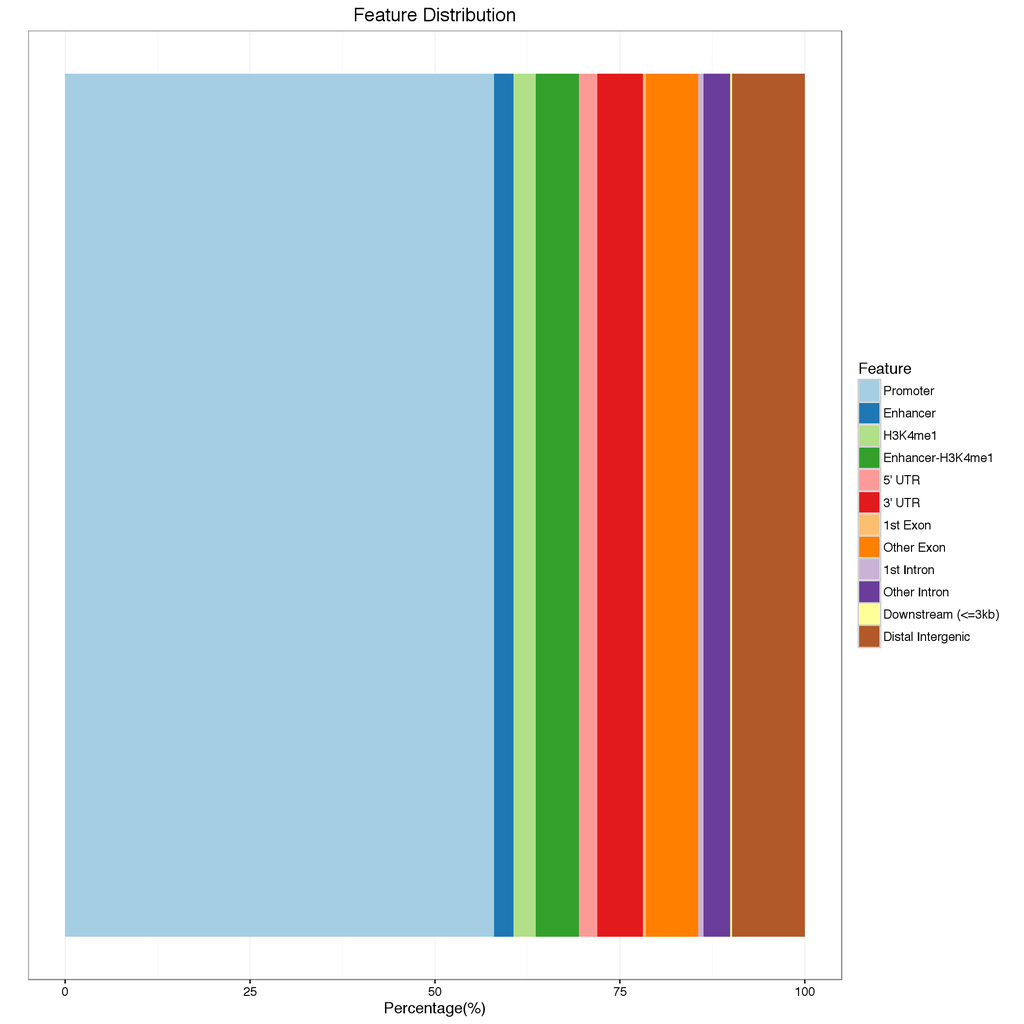

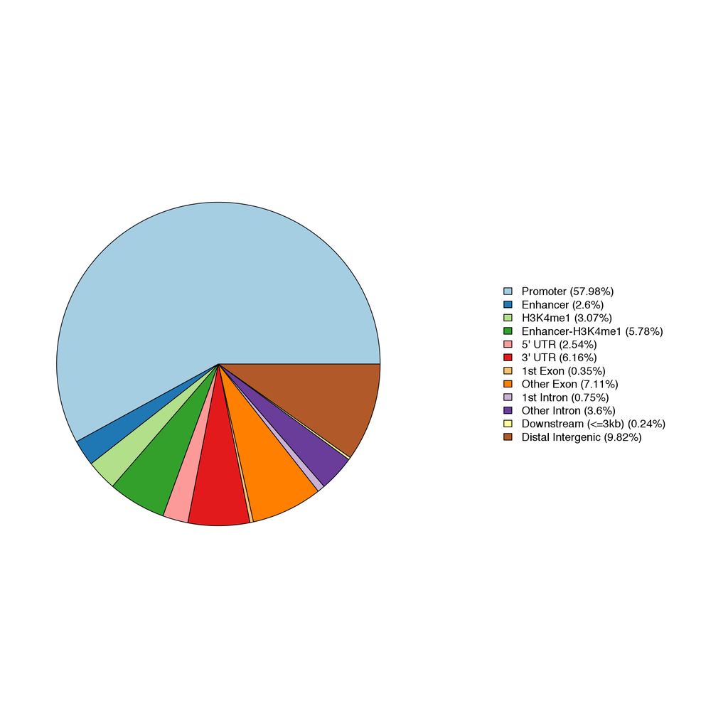

### top_SP140_4h

|  | Feature | Frequency | Numbers |
| --- | --- | --- | --- |
| 12 | Promoter | 52.8279712 | 3596 |
| 7 | Enhancer | 2.4827384 | 169 |
| 9 | H3K4me1 | 3.7608344 | 256 |
| 8 | Enhancer-H3K4me1 | 7.7567210 | 528 |
| 4 | 5’ UTR | 2.7030998 | 184 |
| 3 | 3’ UTR | 6.2876451 | 428 |
| 1 | 1st Exon | 0.3378875 | 23 |
| 10 | Other Exon | 6.2729543 | 427 |
| 2 | 1st Intron | 1.1752608 | 80 |
| 11 | Other Intron | 4.5394447 | 309 |
| 6 | Downstream (<=3kb) | 0.1909799 | 13 |
| 5 | Distal Intergenic | 11.6644631 | 794 |

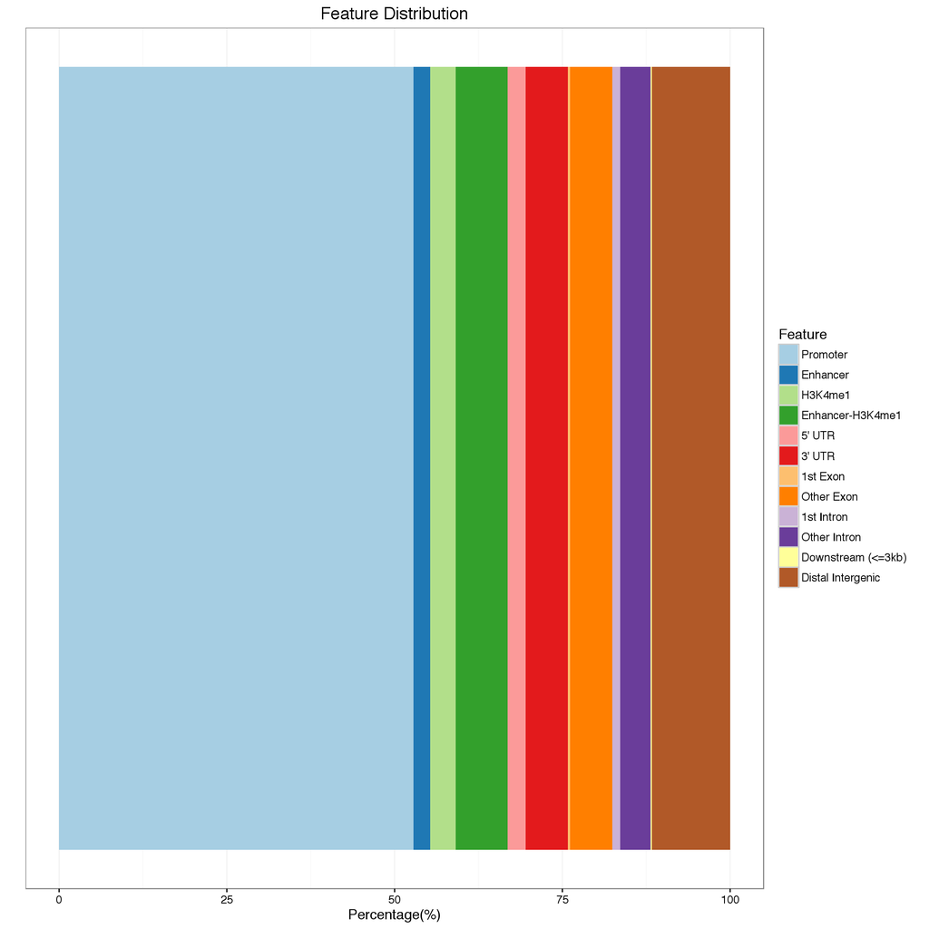

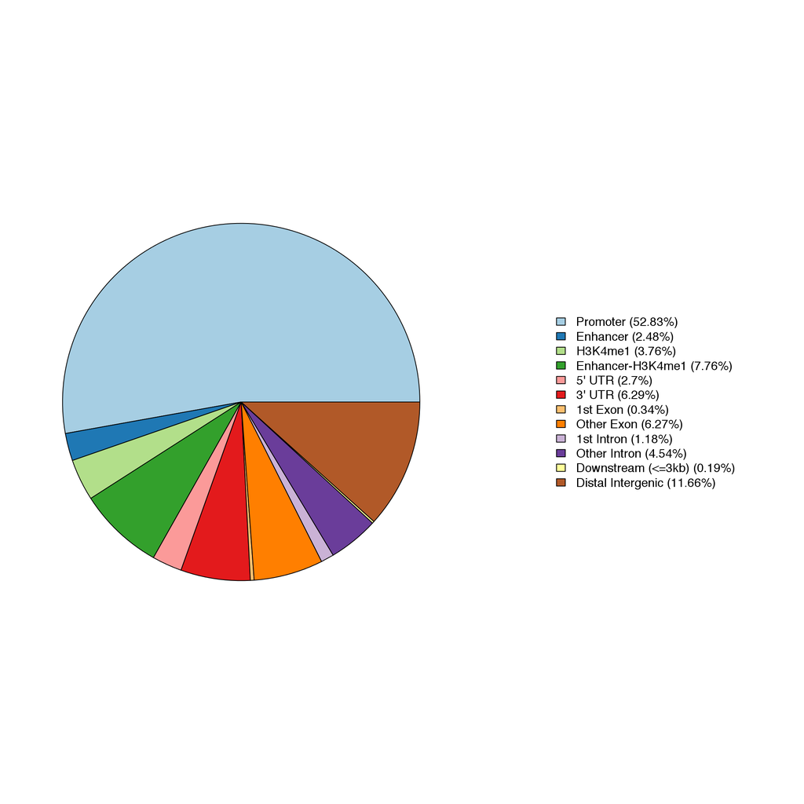

```r
> peakAnnoList_mod = peakAnnoList_mod[1:2]
> names(peakAnnoList_mod) = names(peakAnnoList)
```